```r
library(dplyr)
library(TTR)
library(forecast)
library(lmtest) #digunakan untuk uji formal pendeteksian autokorelasi
```

```r
library(orcutt) #untuk membuat model regresi Cochrane-Orcutt
library(HoRM) #untuk membuat model regresi Hildreth-Lu
library(graphics)
library(TSA)
library(rio)
library(ggplot2)
library(corrplot)
library(RColorBrewer)
library(scales)
```

```r
wine<-read.csv("https://raw.githubusercontent.com/karimatuain/mpdw/main/Data/Data%20MPDW%202.csv")
wine<-as.data.frame(wine)
wine
```

```
##    Year Price.Dollars.Unit. Production HarvestedAcres Yield.Unit.Acre.
## 1  1980              542.00       3918           1660             2.36
## 2  1981              548.00       4860           1725             2.82
## 3  1982              528.00       6326           1610             3.93
## 4  1983              424.00       5042           1640             3.07
## 5  1984              398.00       5286           1672             3.16
## 6  1985              338.00       5336           1501             3.55
## 7  1986              356.00       4908           1465             3.35
## 8  1987              358.00       5006           1458             3.43
## 9  1988              378.00       4094           1216             3.37
## 10 1989              713.00       7615           1812             4.20
## 11 1990              880.00       3435           1628             2.11
## 12 1991              867.00       4938           1286             3.84
## 13 1992              890.00       5028           1531             3.28
## 14 1993              854.00       4248           1572             2.70
```

[output cut: 27 more lines]

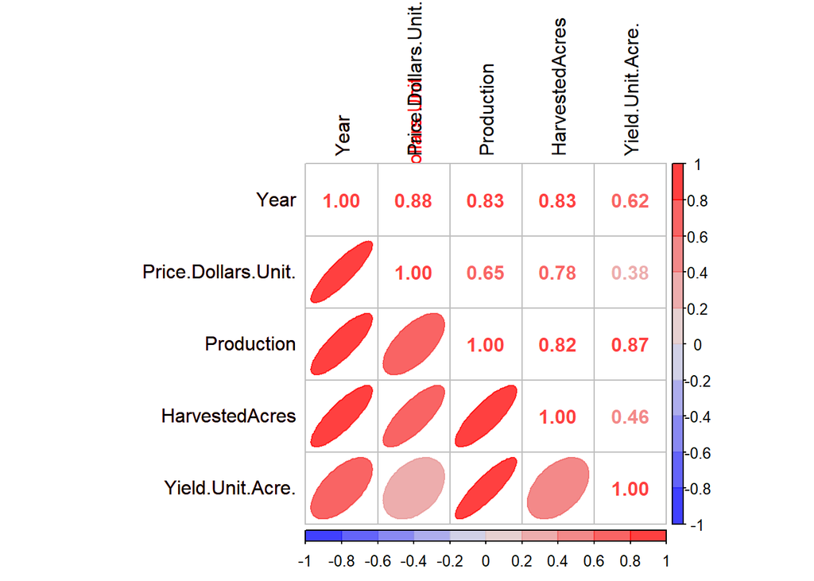

```r
# Matriks korelasi
cormat <- cor(wine)

colors <- alpha(colorRampPalette(c("blue", #Warna Bawah
                                   "#dbdbdb", #Warna Tengah
                                   "red"))(10), #Warna Atas
                                   alpha = 0.75) #Transparan

corrplot(cormat, method = 'ellipse', type='lower', order='original', col=colors)
corrplot(cormat, add=TRUE, method = 'number', type='upper', order='original',
         tl.pos = "lt",
         tl.col = "black", col=colors)
```

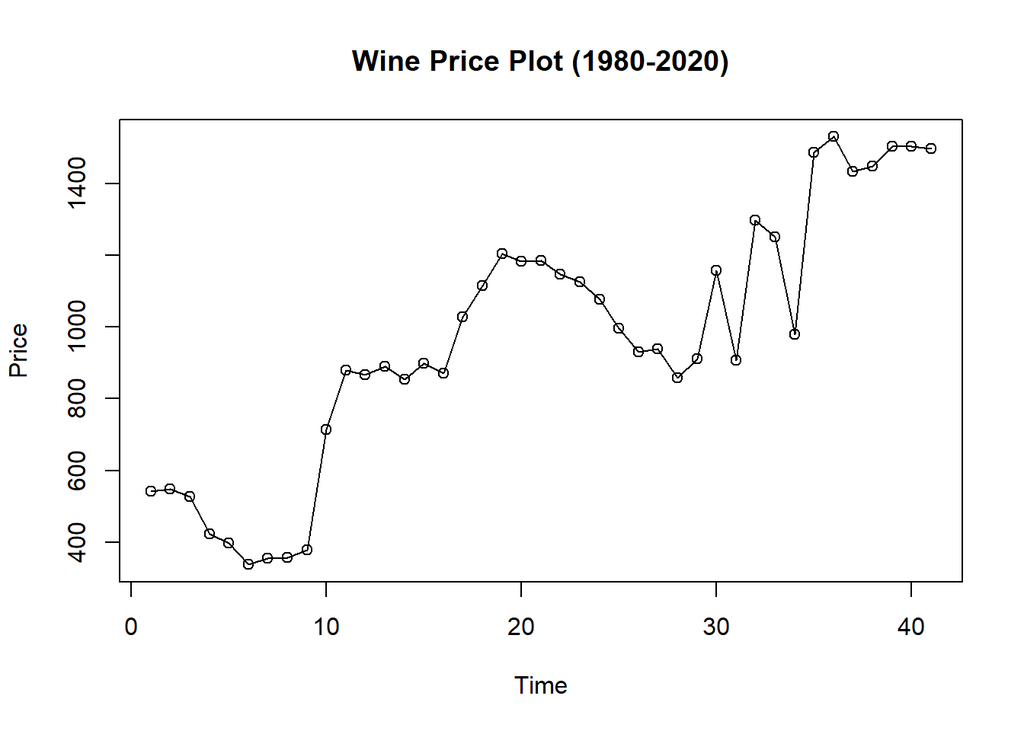

```r
wine.price.ts<-ts(wine$Price.Dollars.Unit.)
wine.prod.ts<-ts(wine$Production)
wine.hararea.ts<-ts(wine$HarvestedAcres)
wine.yield.ts<-ts(wine$Yield.Unit.Acre.)

ts.plot(wine.price.ts,xlab="Time", ylab="Price", main="Wine Price Plot (1980-2020)")
points(wine.price.ts)
```

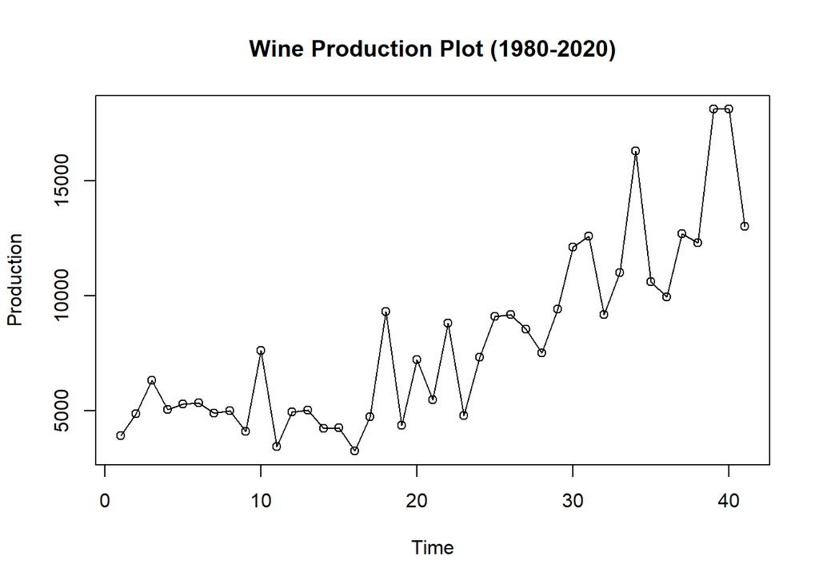

```r
ts.plot(wine.prod.ts,xlab="Time",ylab="Production",main ="Wine Production Plot (1980-2020)")
points(wine.prod.ts)
```

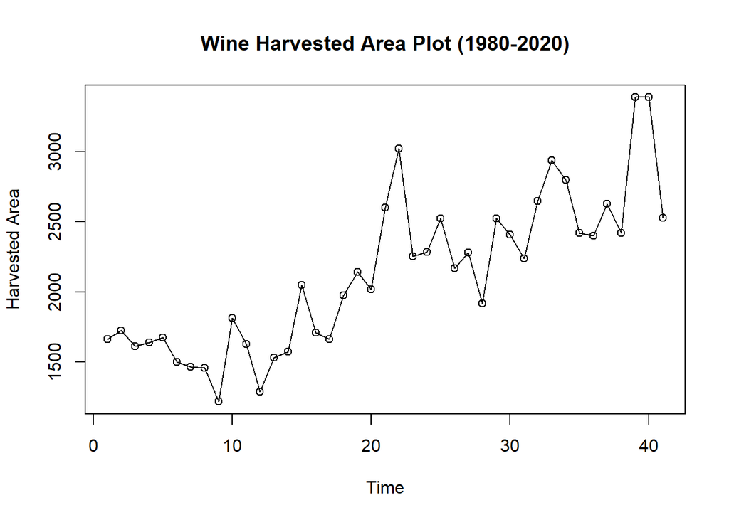

```r
ts.plot(wine.hararea.ts,xlab="Time",ylab="Harvested Area",main ="Wine Harvested Area Plot (1980-2020)")
points(wine.hararea.ts)
```

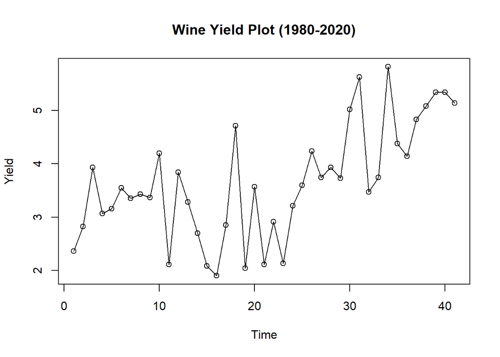

```r
ts.plot(wine.yield.ts,xlab="Time",ylab="Yield",main ="Wine Yield Plot (1980-2020)")
points(wine.yield.ts)
```

```r
#Pembuatan Model Regresi
#model regresi
wine.model<- lm(wine.price.ts~wine.prod.ts+wine.hararea.ts+wine.yield.ts, data = wine)
summary(wine.model)
```

```
##
## Call:
## lm(formula = wine.price.ts ~ wine.prod.ts + wine.hararea.ts +
##     wine.yield.ts, data = wine)
##
## Residuals:
##     Min      1Q  Median      3Q     Max
## -331.25 -178.99  -27.43  204.49  416.06
##
## Coefficients:
##                  Estimate Std. Error t value Pr(>|t|)
## (Intercept)     -386.1325   639.4249  -0.604   0.5496
## wine.prod.ts      -0.0298     0.0723  -0.412   0.6826
## wine.hararea.ts    0.6139     0.2867   2.141   0.0389 *
## wine.yield.ts     77.9870   171.7025   0.454   0.6523
## ---
## Signif. codes:  0 '***' 0.001 '**' 0.01 '*' 0.05 '.' 0.1 ' ' 1
##
## Residual standard error: 233 on 37 degrees of freedom
## Multiple R-squared:  0.6102, Adjusted R-squared:  0.5786
## F-statistic:  19.3 on 3 and 37 DF,  p-value: 1.061e-07
```

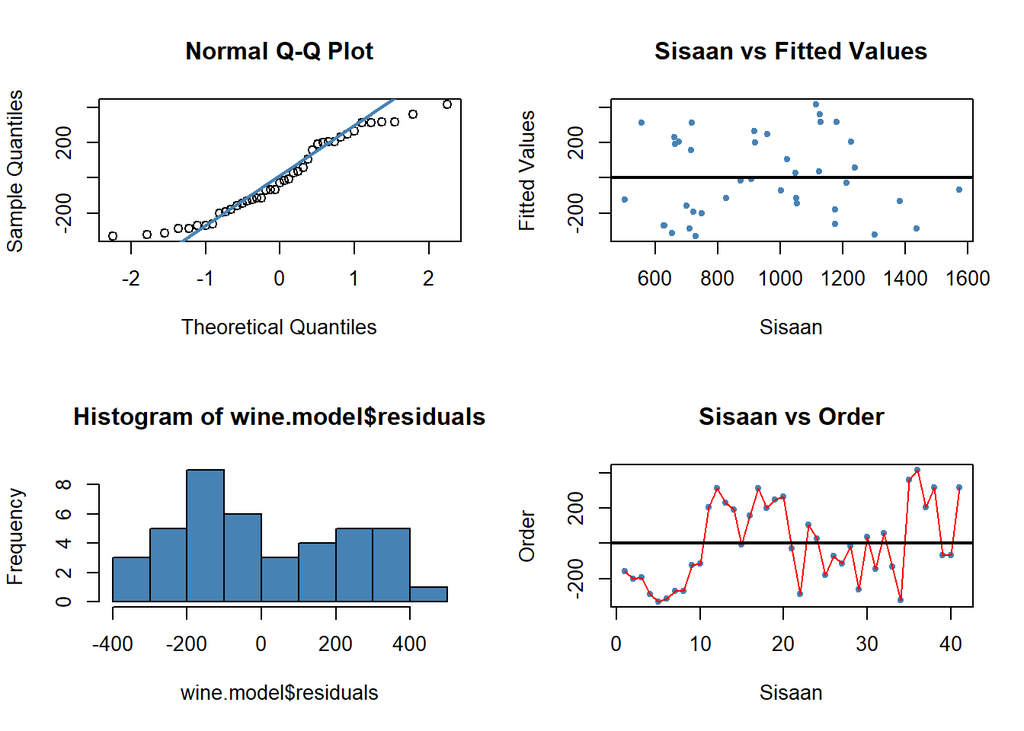

```r
#Diagnostik dengan eksploratif
par(mfrow = c(2,2))
qqnorm(wine.model$residuals)
qqline(wine.model$residuals, col = "steelblue", lwd = 2)
plot(wine.model$fitted.values, wine.model$residuals, col = "steelblue", pch = 20, xlab = "Sisaan", ylab = "Fitted Values", main = "Sisaan vs Fitted Values")
abline(a = 0, b = 0, lwd = 2)
hist(wine.model$residuals, col = "steelblue")
plot(seq(1,41,1), wine.model$residuals, col = "steelblue", pch = 20, xlab = "Sisaan", ylab = "Order", main = "Sisaan vs Order")
lines(seq(1,41,1), wine.model$residuals, col = "red")
abline(a = 0, b = 0, lwd = 2)
```

## Uji Formal Normality Test

```r
#H0: sisaan mengikuti sebaran normal
#H1: sisaan tidak mengikuti sebaran normal
ks.test(wine.model$residuals, "pnorm", mean=mean(wine.model$residuals), sd=sd(wine.model$residuals))
```

```
##
##  Asymptotic one-sample Kolmogorov-Smirnov test
##
## data:  wine.model$residuals
## D = 0.12016, p-value = 0.5946
## alternative hypothesis: two-sided
```

Berdasarkan tes normalitas dengan Kolmogorov-Smirnov Test didapatkan nilai *p-value* > $\alpha$ (5%), artinya cukup bukti untuk menyatakan sisaan menyebar normal.

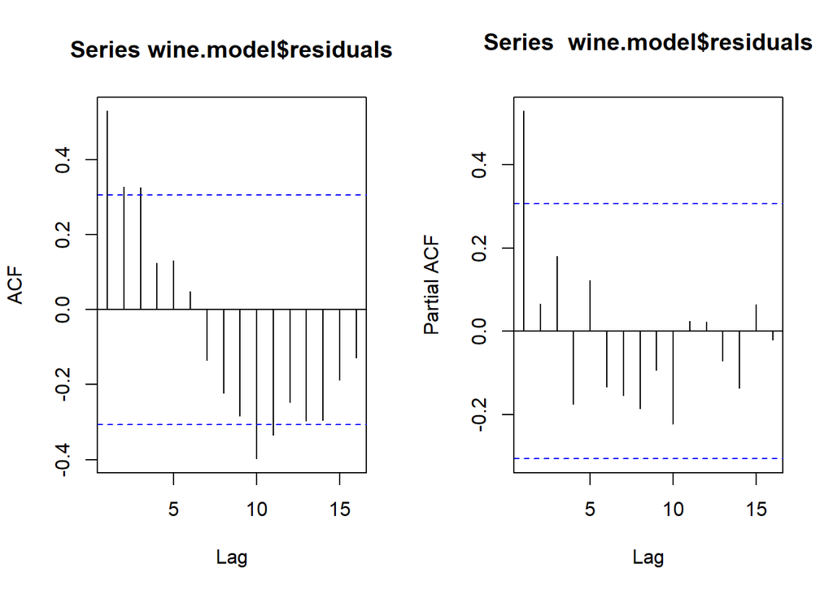

```r
#ACF dan PACF identifikasi autokorelasi
par(mfrow = c(1,2))
acf(wine.model$residuals)
pacf(wine.model$residuals)
```

Berdasarkan plot ACF dan PACF, terlihat bahwa garis melewati batas selang berwarna biru. Itu artinya, terjadi autokorelasi.

```r
#uji-Durbin Watson
#H0: tidak ada autokorelasi
#H1: ada autokorelasi
dwtest(wine.model)
```

```
##
##  Durbin-Watson test
##
## data:  wine.model
## DW = 0.87954, p-value = 8.703e-06
## alternative hypothesis: true autocorrelation is greater than 0
```

Berdasarkan hasil Durbin-Watson Test, didapatkan nilai p-value = $8.703e-06$ < alpha 5%, artinya terjadi autokorelasi. Didapatkan juga nilai $DW = 0.87954$. Berdasarkan tabel Durbin-Watson diperoleh nilai $DL = 1.3480$ dan $DU = 1.6603$. Nilai DW berada di antara nilai 0 dan DL. Artinya, terjadi autokorelasi positif.

## Penanganan Autokorelasi

### Metode Cochrane-Orcutt

```r
#Penanganan Autokorelasi Cochrane-Orcutt
wine.model.co<-cochrane.orcutt(wine.model)
wine.model.co
```

```
## Cochrane-orcutt estimation for first order autocorrelation
##
## Call:
## lm(formula = wine.price.ts ~ wine.prod.ts + wine.hararea.ts +
##     wine.yield.ts, data = wine)
##
##  number of interaction: 51
##  rho 0.958395
##
## Durbin-Watson statistic
## (original):    0.87954 , p-value: 8.703e-06
## (transformed): 2.22128 , p-value: 8.04e-01
##
##  coefficients:
##     (Intercept)    wine.prod.ts wine.hararea.ts   wine.yield.ts
##      855.920135       -0.089392        0.421172      142.379708
```

```r
dwtest(wine.model.co)
```

```
##
##  Durbin-Watson test
##
## data:  wine.model.co
## DW = 2.2213, p-value = 0.804
## alternative hypothesis: true autocorrelation is greater than 0
```

```r
#Rho optimum
rho<- wine.model.co$rho
rho
```

```
## [1] 0.9583948
```

```r
#Transformasi Manual
wine.price.trans<- wine$Price.Dollars.Unit.[-1]-wine$Price.Dollars.Unit.[-41]*rho
wine.prod.trans<- wine$Production[-1]-wine$Production[-41]*rho
wine.hararea.trans<- wine$HarvestedAcres[-1]-wine$HarvestedAcres[-41]*rho
wine.yield.trans<- wine$Yield.Unit.Acre.[-1]-wine$Yield.Unit.Acre.[-41]*rho

wine.model.co.manual<- lm(wine.price.trans~wine.prod.trans+wine.hararea.trans+wine.yield.trans)
summary(wine.model.co.manual)
```

```
##
## Call:
## lm(formula = wine.price.trans ~ wine.prod.trans + wine.hararea.trans +
##     wine.yield.trans)
##
## Residuals:
##     Min      1Q  Median      3Q     Max
## -237.67  -60.60  -29.89   29.10  344.73
##
## Coefficients:
##                     Estimate Std. Error t value Pr(>|t|)
## (Intercept)         35.61073   25.20086   1.413   0.1662
## wine.prod.trans     -0.08939    0.03604  -2.480   0.0179 *
## wine.hararea.trans   0.42117    0.15734   2.677   0.0111 *
## wine.yield.trans   142.37971   80.08522   1.778   0.0839 .
## ---
## Signif. codes:  0 '***' 0.001 '**' 0.01 '*' 0.05 '.' 0.1 ' ' 1
##
## Residual standard error: 126.7 on 36 degrees of freedom
## Multiple R-squared:  0.2832, Adjusted R-squared:  0.2234
## F-statistic:  4.74 on 3 and 36 DF,  p-value: 0.006903
```

```r
#Mencari Penduga Koefisien Regresi setelah Transformasi ke Persamaan Awal
b0bintang <- wine.model.co.manual$coefficients[-c(2,3,4)]
b0 <- b0bintang/(1-rho)
b1 <- wine.model.co.manual$coefficients[-c(1,3,4)]
b2 <- wine.model.co.manual$coefficients[-c(1,2,4)]
b3 <- wine.model.co.manual$coefficients[-c(1,2,3)]
b0
```

```
## (Intercept)
##    855.9201
```

```r
b1
```

```
## wine.prod.trans
##     -0.08939198
```

```r
b2
```

```
## wine.hararea.trans
##          0.4211716
```

```r
b3
```

```
## wine.yield.trans
##         142.3797
```

Penanganan autokorelasi menggunakan fungsi dan manual menunjukkan hasil yang sama.

### Metode Hildreth-Lu

```r
#Penanganan Autokorelasi Hildreth lu
# Hildreth-Lu
hildreth.lu.func<- function(r, model){
  x1 <- model.matrix(model)[,2]
  x2 <- model.matrix(model)[,3]
  x3 <- model.matrix(model)[,4]
  y <- model.response(model.frame(model))
  n <- length(y)
  t <- 2:n
  y <- y[t]-r*y[t-1]
  x1 <- x1[t]-r*x1[t-1]
  x2 <- x2[t]-r*x2[t-1]
  x3 <- x3[t]-r*x3[t-1]

  return(lm(y~x1+x2+x3))
}

#Pencarian rho yang meminimumkan SSE
r <- c(seq(0.1,0.9, by= 0.1))
rho.tab <- data.frame("rho" = r, "SSE" = sapply(r, function(i){deviance(hildreth.lu.func(i, wine.model))}))
round(rho.tab, 4)
```

```
##   rho       SSE
## 1 0.1 1780937.7
## 2 0.2 1604661.2
## 3 0.3 1445291.4
## 4 0.4 1294287.9
## 5 0.5 1142460.8
## 6 0.6  984039.2
## 7 0.7  823763.4
## 8 0.8  682626.1
## 9 0.9  593674.9
```

Pertama-tama akan dicari di mana kira-kira $ρ$ yang menghasilkan SSE minimum. Pada hasil di atas terlihat $ρ$ minimum ketika 0.9. Namun, hasil tersebut masih kurang teliti sehingga akan dicari kembali $ρ$ yang lebih optimum dengan ketelitian yang lebih. Jika sebelumnya jarak antar $ρ$ yang dicari adalah 0.1, kali ini jarak antar $ρ$ adalah 0.001 dan dilakukan pada selang 0.8 sampai dengan 0.9.

```r
#Rho optimal di sekitar 0.9
rho.opt <- seq(0.8,0.9, by= 0.001)
rho.tab.opt <- data.frame("rho" = rho.opt, "SSE" = sapply(rho.opt, function(i){deviance(hildreth.lu.func(i, wine.model))}))
head(rho.tab.opt[order(rho.tab.opt$SSE),])
```

```
##       rho      SSE
## 101 0.900 593674.9
## 100 0.899 594197.5
## 99  0.898 594728.4
## 98  0.897 595267.5
## 97  0.896 595815.0
## 96  0.895 596370.6
```

[figure not shown]

```r
#Grafik SSE optimum
par(mfrow = c(1,1))
plot(rho.tab$SSE ~ rho.tab$rho ,xlim=c(0.0,1.5), type = "l", xlab = "Rho", ylab = "SSE")
abline(v = rho.tab.opt[rho.tab.opt$SSE==min(rho.tab.opt$SSE),"rho"], lty = 2, col="red",lwd=2)
text(x=0.958, y=593674.9    , labels = "rho=0.958", cex = 0.8)
```

Perhitungan yang dilakukan aplikasi `R` menunjukkan bahwa nilai $ρ$ optimum, yaitu saat SSE terkecil terdapat pada nilai $ρ=0.900$. Hal tersebut juga ditunjukkan pada plot. Selanjutnya, model dapat didapatkan dengan mengevaluasi nilai $ρ$ ke dalam fungsi `hildreth.lu.func`, serta dilanjutkan dengan pengujian autokorelasi dengan uji Durbin-Watson. Namun, setelah pengecekan tersebut tidak lupa koefisien regresi tersebut digunakan untuk transformasi balik. Persamaan hasil transformasi itulah yang menjadi persamaan sesungguhnya.

```r
#Model terbaik
wine.model.hl <- hildreth.lu.func(0.900, wine.model)
summary(wine.model.hl)
```

```
##
## Call:
## lm(formula = y ~ x1 + x2 + x3)
##
## Residuals:
##     Min      1Q  Median      3Q     Max
## -222.03  -66.85  -24.76   54.31  363.27
##
## Coefficients:
##              Estimate Std. Error t value Pr(>|t|)
## (Intercept)  48.43435   41.71456   1.161   0.2532
## x1           -0.08753    0.03757  -2.330   0.0255 *
## x2            0.42449    0.16390   2.590   0.0138 *
## x3          140.56158   83.54091   1.683   0.1011
## ---
## Signif. codes:  0 '***' 0.001 '**' 0.01 '*' 0.05 '.' 0.1 ' ' 1
##
## Residual standard error: 128.4 on 36 degrees of freedom
## Multiple R-squared:  0.2624, Adjusted R-squared:  0.2009
## F-statistic: 4.269 on 3 and 36 DF,  p-value: 0.01118
```

```r
#Transformasi Balik
cat("y = ", coef(wine.model.hl)[1]/(1-0.900), "+", coef(wine.model.hl)[2],"x1","+", coef(wine.model.hl)[3],"x2","+", coef(wine.model.hl)[4],"x3", sep = "")
```

```
## y = 484.3435+-0.087533x1+0.4244931x2+140.5616x3
```

Setelah dilakukan tranformasi balik, didapatkan model dengan metode Hildreth-Lu sebagai berikut.
$$y_i=484.3435-0.087533x1_t+0.4244931x2_t+140.5616x3_t$$

```r
#Deteksi autokorelasi
dwtest(wine.model.hl)
```

```
##
##  Durbin-Watson test
##
## data:  wine.model.hl
## DW = 2.0527, p-value = 0.627
## alternative hypothesis: true autocorrelation is greater than 0
```

Hasil uji Durbin-Watson juga menunjukkan bahwa nilai DW meningkat menjadi $2.0527$. Nilai DW sudah berada pada rentang DU < DW < 4-DU atau $1.6603 < DW < 2.3397$, maka sudah tidak ada autokorelasi positif. Hal tersebut juga didukung oleh *p-value* sebesar $0.627$, di mana $p-value > 0.05$ ($\alpha$). Artinya tak tolak $H_0$ atau belum cukup bukti menyatakan bahwa ada autokorelasi pada taraf nyata 5%.

Terakhir, akan dibandingkan nilai SSE dari ketiga metode (metode awal, metode Cochrane-Orcutt, dan Hildreth-Lu).

```r
#Perbandingan
sseModelawal <- anova(wine.model)$`Sum Sq`[-c(1,2,3)]
sseModelCO <- anova(wine.model.co.manual)$`Sum Sq`[-c(1,2,3)]
sseModelHL <- anova(wine.model.hl)$`Sum Sq`[-c(1,2,3)]
mseModelawal <- sseModelawal/length(wine$Price.Dollars.Unit.)
mseModelCO <- sseModelCO/length(wine$Price.Dollars.Unit.)
mseModelHL <- sseModelHL/length(wine$Price.Dollars.Unit.)
akurasi <- matrix(c(sseModelawal,sseModelCO,sseModelHL,
                    mseModelawal,mseModelCO,mseModelHL),nrow=2,ncol=3,byrow = T)
colnames(akurasi) <- c("Model Awal", "Model Cochrane-Orcutt", "Model Hildreth-Lu")
row.names(akurasi) <- c("SSE","MSE")
akurasi
```

```
##     Model Awal Model Cochrane-Orcutt Model Hildreth-Lu
## SSE 2008749.08             578262.83         593674.87
## MSE   48993.88              14103.97          14479.87
```

Berdasarkan hasil tersebut dapat diketahui bahwa hasil penanganan autokorelasi dengan metode Cochrane-Orcutt dan Hildreth-Lu,tampak SSE yang dihasilkan metode Cochrane-Orcutt lebih kecil dari metode Hildreth-Lu,sebesar $578262.83$ pada metode Cochrane-Orcutt dan $ 593674.87$ pada metode Hildreth-Lu. Nilai tersebut lebih baik dibandingkan model awal ketika autokorelasi masih terjadi, yaitu sebesar $2008749.08$.

# Simpulan

Autokorelasi yang terdapat pada data California Wine Production (untuk kota Alameda) tahun 1980-2020 terjadi akibat adanya korelasi di antara unsur penyusunnya. Adanya autokorelasi menyebabkan model regresi kurang baik karena akan meingkatkan galatnya. Autokorelasi dapat dideteksi secara eksploratif melalui plot sisaan, ACF, dan PACF, serta dengan uji formal Durbin-Watson. Autokorelasi tersebut dapat ditangani dengan metode Cochrane-Orcutt dan Hildreth-Lu. Kedua metode menghasilkan nilai SSE yang tidak jauh berbeda, artinya keduanya baik untuk digunakan.